# Project Business Statistics: E-news Express

**Marks: 60**

## Define Problem Statement and Objectives

Problem Statement:  
E-news Express is an online news portal whose goal is to increase subscribers and drive engagement. The design team of the company has researched and created a new landing page with a new outline & more relevant content shown compared to the old page. To test the effectiveness of the new landing page, the data science team randomly selected 100 users and divided them equally into two groups, where one group was shown the old page and one group was shown the new landing page. Data was collected to analyze how users interacted with each page.

Objectives:

- Do the users spend more time on the new landing page than on the existing landing page?
- Is the conversion rate (the proportion of users who visit the landing page and get converted) for the new page greater than the conversion rate for the old page?
- Does the converted status depend on the preferred language?
- Is the time spent on the new page the same for the different language users?

## Import all the necessary libraries

```python
import pandas as pd
import numpy as np
import matplotlib.pyplot as plt
import seaborn as sns
%matplotlib inline
import scipy.stats as stats
```

## Reading the Data into a DataFrame

```python
from google.colab import drive
drive.mount('/content/drive')
```

```python
data = pd.read_csv('/content/drive/My Drive/Data Science/GL Projects/abtest.csv')
```

## Explore the dataset and extract insights using Exploratory Data Analysis

- Data Overview
  - Viewing the first and last few rows of the dataset
  - Checking the shape of the dataset
  - Getting the statistical summary for the variables
- Check for missing values
- Check for duplicates

```python
# Display the first 5 and last 5 rows of the data

data
```

|  | user_id | group | landing_page | time_spent_on_the_page | converted | language_preferred |
| --- | --- | --- | --- | --- | --- | --- |
| 0 | 546592 | control | old | 3.48 | no | Spanish |
| 1 | 546468 | treatment | new | 7.13 | yes | English |
| 2 | 546462 | treatment | new | 4.40 | no | Spanish |
| 3 | 546567 | control | old | 3.02 | no | French |
| 4 | 546459 | treatment | new | 4.75 | yes | Spanish |
| ... | ... | ... | ... | ... | ... | ... |
| 95 | 546446 | treatment | new | 5.15 | no | Spanish |
| 96 | 546544 | control | old | 6.52 | yes | English |
| 97 | 546472 | treatment | new | 7.07 | yes | Spanish |
| 98 | 546481 | treatment | new | 6.20 | yes | Spanish |
| 99 | 546483 | treatment | new | 5.86 | yes | English |

100 rows × 6 columns

```python
# Use .shape attribute to return number of rows & columns in the data

print(f'There are {data.shape[0]} rows & {data.shape[1]} columns.')
```

```
There are 100 rows & 6 columns.
```

```python
# Use .describe() method to display statistical summary of numerical variable (drop user_id column as it is not numerical)

data.describe().T.drop('user_id')
```

|  | count | mean | std | min | 25% | 50% | 75% | max |
| --- | --- | --- | --- | --- | --- | --- | --- | --- |
| time_spent_on_the_page | 100.0 | 5.3778 | 2.378166 | 0.19 | 3.88 | 5.415 | 7.0225 | 10.71 |

Time spent on the page ranges from 0.19 minutes (11.4 seconds) to 10.7 minutes. Average time spent on the page is 5.4 minutes with standard deviation of 2.4 minutes. Median time spend on the page is 5.4 minutes.

```python
# Use include='object' parameter to display summary of categorical variables

data.describe(include='object').T
```

|  | count | unique | top | freq |
| --- | --- | --- | --- | --- |
| group | 100 | 2 | control | 50 |
| landing_page | 100 | 2 | old | 50 |
| converted | 100 | 2 | yes | 54 |
| language_preferred | 100 | 3 | Spanish | 34 |

There are 2 groups of equal frequency (one for each landing page). There are 3 different preferred languages, the most common being Spanish.

```python
# Use .info() method to check non-null counts and column datatypes

data.info()
```

```
<class 'pandas.core.frame.DataFrame'>
RangeIndex: 100 entries, 0 to 99
Data columns (total 6 columns):
 #   Column                  Non-Null Count  Dtype
---  ------                  --------------  -----
 0   user_id                 100 non-null    int64
 1   group                   100 non-null    object
 2   landing_page            100 non-null    object
 3   time_spent_on_the_page  100 non-null    float64
 4   converted               100 non-null    object
 5   language_preferred      100 non-null    object
dtypes: float64(1), int64(1), object(4)
memory usage: 4.8+ KB
```

There are 2 columns with numerical datatypes: user_id and time_spent_on_the_page  
The rest of the columns are string/object types: group, landing_page, converted, & language_preferred

```python
# Use .isnull() and .sum() methods to verify there are no missing (null) values

data.isnull().sum()
```

```
user_id                   0
group                     0
landing_page              0
time_spent_on_the_page    0
converted                 0
language_preferred        0
dtype: int64
```

There are no missing values in the data.

```python
# Use .duplicated() and .sum() methods to check for duplicated data

data.duplicated().sum()
```

```
0
```

There are no duplicates in the data.

### Univariate Analysis

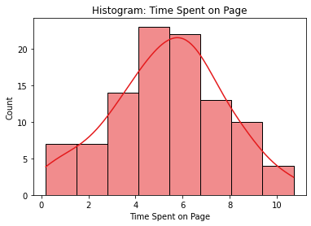

```python
# Use histogram to visualize numerical variable

sns.set_palette("Set1")
sns.histplot(data, x='time_spent_on_the_page', kde=True)
plt.title('Histogram: Time Spent on Page')
plt.xlabel('Time Spent on Page');
```

Time spent on the page appears to follow a normal distribution pattern.

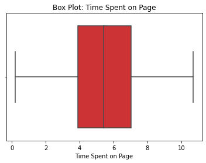

```python
# Use boxplot to visualize numerical variable

sns.boxplot(data=data, x='time_spent_on_the_page')
plt.title('Box Plot: Time Spent on Page')
plt.xlabel('Time Spent on Page');
```

The box plot confirms that time spent on the page is not skewed and there are no outliers.

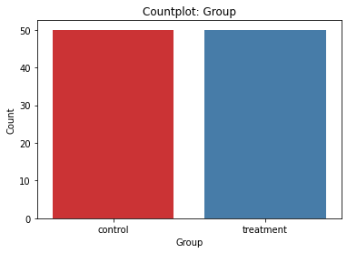

```python
# Use countplot to visualize categorical variables

sns.countplot(data=data, x='group')
plt.title('Countplot: Group')
plt.xlabel('Group')
plt.ylabel('Count');
```

The number of users in the control group is equal to the number of users in the treatment group (50 in each group).

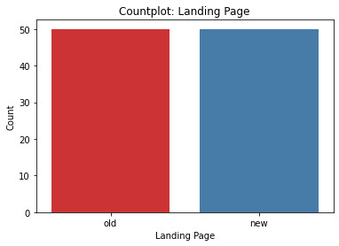

```python
sns.countplot(data=data, x='landing_page')
plt.title('Countplot: Landing Page')
plt.xlabel('Landing Page')
plt.ylabel('Count');
```

The number of users directed to the old landing page (control group) is equal to the number of users directed to the new landing page (treatment group).

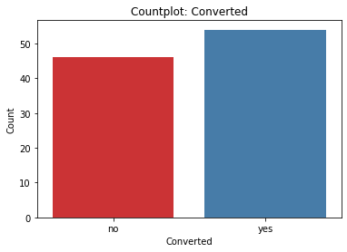

```python
sns.countplot(data=data, x='converted')
plt.title('Countplot: Converted')
plt.xlabel('Converted')
plt.ylabel('Count');
```

More users were converted compared to not-converted.

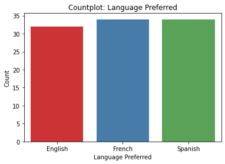

```python
sns.countplot(data=data.sort_values('language_preferred'), x='language_preferred')
plt.title('Countplot: Language Preferred')
plt.xlabel('Language Preferred')
plt.ylabel('Count');
```

The number of users preferring Spanish and French are equal, and both are slightly more common than users preferring English.

### Bivariate Analysis

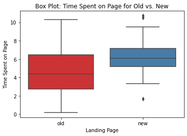

```python
sns.boxplot(data=data, x='landing_page', y='time_spent_on_the_page')
plt.title('Box Plot: Time Spent on Page for Old vs. New')
plt.xlabel('Landing Page')
plt.ylabel('Time Spent on Page');
```

It appears that users spend more time on the new landing page compared to the old landing page. There are some high and low outliers for time spent on the new landing page. There is less variation in time spent on the new page compared to the old page.

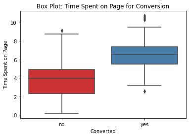

```python
sns.boxplot(data=data, x='converted', y='time_spent_on_the_page')
plt.title('Box Plot: Time Spent on Page for Conversion')
plt.xlabel('Converted')
plt.ylabel('Time Spent on Page');
```

It appears that users who are converted spend more time on the landing page with less variation compared to users who are not converted. There are some outliers in both categories.

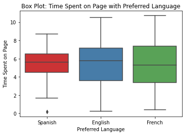

```python
sns.boxplot(data=data, x='language_preferred', y='time_spent_on_the_page')
plt.title('Box Plot: Time Spent on Page with Preferred Language')
plt.xlabel('Preferred Language')
plt.ylabel('Time Spent on Page');
```

The time spent on the page appears to be similar across the preferred languages. The variation is smaller for users who prefer Spanish, with one low outlier.

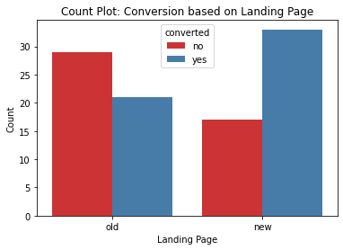

```python
sns.countplot(data=data, x='landing_page', hue='converted')
plt.title('Count Plot: Conversion based on Landing Page')
plt.xlabel('Landing Page')
plt.ylabel('Count');
```

It appears that users who visited the new landing page were more likely to be converted than not, while users who visited the old landing page were less likely to be converted.

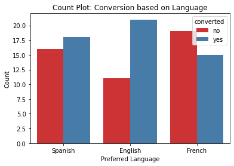

```python
sns.countplot(data=data, x='language_preferred', hue='converted')
plt.title('Count Plot: Conversion based on Language')
plt.xlabel('Preferred Language')
plt.ylabel('Count');
```

It appears that users who prefer English were substantially more likely to be converted than not, while users preferring French were less likely to be converted. Conversion counts were similar across users who prefer Spanish.

## 1. Do the users spend more time on the new landing page than the existing landing page?

### Perform Visual Analysis

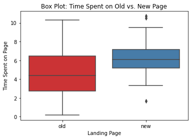

```python
sns.boxplot(data=data, x='landing_page', y='time_spent_on_the_page')
plt.title('Box Plot: Time Spent on Old vs. New Page')
plt.xlabel('Landing Page')
plt.ylabel('Time Spent on Page');
```

It appears that users spend more time on the new landing page compared to the old page.

### Step 1: Define the null and alternate hypotheses

Null hypothesis: average time spent on new landing page is equal to time spent on old landing page

Alternate hypothesis: average time spent on new landing page is greater than time spent on old landing page

### Step 2: Select Appropriate test

Since we are comparing means from two independent samples with unknown population standard deviation, the student's t-test is appropriate. The data is continuous, normally distributed and randomly sampled so the assumptions for the t-test are met.

### Step 3: Decide the significance level

Significance level of 0.05 will provide 95% certainty of avoiding Type I error (false positive).

### Step 4: Collect and prepare data

```python
# Create new DataFrames to separate data for old landing page vs. new landing page. Calculate mean and standard deviation for each.

data_old = data[data['landing_page']=='old'].reset_index(drop=True)
data_new = data[data['landing_page']=='new'].reset_index(drop=True)

print(f'The average time spent on the old landing page is {round(data_old["time_spent_on_the_page"].mean(),2)} minutes with standard deviation of {round(data_old["time_spent_on_the_page"].std(),2)} minutes')
print(f'The average time spent on the new landing page is {round(data_new["time_spent_on_the_page"].mean(),2)} minutes with standard deviation of {round(data_new["time_spent_on_the_page"].std(),2)} minutes')
```

```
The average time spent on the old landing page is 4.53 minutes with standard deviation of 2.58 minutes
The average time spent on the new landing page is 6.22 minutes with standard deviation of 1.82 minutes
```

The sample standard deviations are unequal.

### Step 5: Calculate the p-value

```python
# Use independent t-test function with equal_var=False to indicate that sample standard deviations are not equal.

from scipy.stats import ttest_ind
test_stat, p_value = ttest_ind(data_new['time_spent_on_the_page'],data_old['time_spent_on_the_page'], equal_var=False, alternative='greater')
print(f'The p-value is {p_value}')
```

```
The p-value is 0.0001392381225166549
```

### Step 6: Compare the p-value with $\alpha$

The p-value is less than the level of significance (alpha = 0.05). Therefore, there is enough evidence to reject the null hypothesis.

### Step 7: Draw inference

The null hypothesis is rejected, which means we can be 95% certain that the time spent on the old and new page is NOT equal; time spent on the new page is greater.

## 2. Is the conversion rate (the proportion of users who visit the landing page and get converted) for the new page greater than the conversion rate for the old page?

```python
# Create a new DataFrame to count conversions

conversions = pd.DataFrame({
    'Page':['New page','Old page'],
    'Converted':
      [data_new['converted'][data_new['converted']=='yes'].count(),
       data_old['converted'][data_old['converted']=='yes'].count()],
    'Not converted':
      [data_new['converted'][data_new['converted']=='no'].count(),
       data_old['converted'][data_old['converted']=='no'].count()],
    'Sample size':[data_new.shape[0],data_old.shape[0]]})

conversions
```

|  | Page | Converted | Not converted | Sample size |
| --- | --- | --- | --- | --- |
| 0 | New page | 33 | 17 | 50 |
| 1 | Old page | 21 | 29 | 50 |

```python
# Add a new column to calculate conversion rate (number of users converted out of each sample)

conversions['Conversion Rate'] = conversions['Converted']/conversions['Sample size']
conversions
```

|  | Page | Converted | Not converted | Sample size | Conversion Rate |
| --- | --- | --- | --- | --- | --- |
| 0 | New page | 33 | 17 | 50 | 0.66 |
| 1 | Old page | 21 | 29 | 50 | 0.42 |

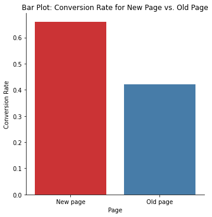

```python
# Use a bar plot to visualize difference between conversion rate for old page vs. new page

sns.catplot(data=conversions, x='Page', y='Conversion Rate', kind='bar')
plt.title('Bar Plot: Conversion Rate for New Page vs. Old Page');
```

It appears that the conversion rate is higher for the new page compared to the old page.

Null hypothesis: the conversion rates are equal for the old page and the new page  
Alternative hypothesis: the conversion rate for the new page is higher than the old page

Since we are comparing proportions from 2 independent samples, the 2-sample z-test is the appropriate test. The following assumptions for the 2-sample z-test are met:

- Binomial distribution (yes/no conversion)
- Independent populations
- Random sampling
- np and n(1-p) [number of successes & failures in each group] are each > 10

Significance level of 0.05 will provide 95% certainty of avoiding Type I error (false positive).

```python
# Use NumPy arrays of conversion counts and number of observations in each category to execute the proportions_ztest function

conversion_count = np.array(conversions['Converted'])
nobs = np.array(conversions['Sample size'])

from statsmodels.stats.proportion import proportions_ztest
test_stat, p_value = proportions_ztest(conversion_count, nobs)
print(f'The p-value is {p_value}')
```

```
The p-value is 0.016052616408112556
```

The p-value is less than the level of significance of 0.05, therefore there is enough evidence to reject the null hypothesis and conclude that the conversion rate for the new page is in fact higher than the conversion rate for the old page.

## 3. Is the conversion and preferred language are independent or related?

```python
# Create new DataFrames to separate data by preferred language

data_eng = data[data['language_preferred']=='English']
data_fren = data[data['language_preferred']=='French']
data_span = data[data['language_preferred']=='Spanish']
```

```python
# Create a contingency table for conversion and preferred language

lang_table = pd.DataFrame({
    'Language':['English','French','Spanish'],
    'Converted':
      [data_eng['converted'][data_eng['converted']=='yes'].count(),
       data_fren['converted'][data_fren['converted']=='yes'].count(),
       data_span['converted'][data_span['converted']=='yes'].count()],
    'Not converted':
      [data_eng['converted'][data_eng['converted']=='no'].count(),
       data_fren['converted'][data_fren['converted']=='no'].count(),
       data_span['converted'][data_span['converted']=='no'].count()],
    'Sample size':[data_eng.shape[0],data_fren.shape[0],data_span.shape[0]]})

lang_table
```

|  | Language | Converted | Not converted | Sample size |
| --- | --- | --- | --- | --- |
| 0 | English | 21 | 11 | 32 |
| 1 | French | 15 | 19 | 34 |
| 2 | Spanish | 18 | 16 | 34 |

```python
# Add a column with the conversion rate for each language

lang_table['Conversion rate'] = round(lang_table['Converted']/lang_table['Sample size'],2)
lang_table
```

|  | Language | Converted | Not converted | Sample size | Conversion rate |
| --- | --- | --- | --- | --- | --- |
| 0 | English | 21 | 11 | 32 | 0.66 |
| 1 | French | 15 | 19 | 34 | 0.44 |
| 2 | Spanish | 18 | 16 | 34 | 0.53 |

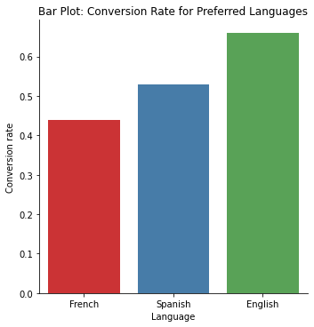

```python
# Use a bar plot to visualize conversion rates for each language

sns.catplot(data=lang_table.sort_values('Conversion rate'), x='Language', y='Conversion rate', kind='bar')
plt.title('Bar Plot: Conversion Rate for Preferred Languages');
```

It appears that the conversion rate is highest for users who prefer English and lowest for users who prefer French. The conversion rate for users who prefer Spanish is in the middle.

Null hypothesis: preferred language and conversion rate are independent  
Alternate hypothesis: preferred language and conversion rate are not independent

Since we want to know if 2 categorical variables are independent, the chi-squared test is appropriate. There are more than 5 observations for each category and the samples are random, so the necessary assumptions are met.

Significance level of 0.05 will provide 95% certainty of avoiding Type I error (false positive).

```python
# Use chi2_contingency function to find the p-value from the contingency table

from scipy.stats import chi2_contingency
chi, p_value, dof, expected = chi2_contingency(lang_table.drop(['Language','Sample size','Conversion rate'], axis = 1))
print(f'The p-value is {p_value}')
```

```
The p-value is 0.2129888748754345
```

Since the p-value is greater than the level of significance (0.05), there is NOT enough evidence to reject the null hypothesis. Therefore we maintain that preferred language and conversion rate are independent.

## 4. Is the time spent on the new page same for the different language users?

```python
# Use indexing of separate DataFrames by language with .mean() method to find average time spent on the new landing page

eng_time = round(data_eng[data_eng["landing_page"]=="new"]["time_spent_on_the_page"].mean(),2)
fren_time = round(data_fren[data_fren["landing_page"]=="new"]["time_spent_on_the_page"].mean(),2)
span_time = round(data_span[data_span["landing_page"]=="new"]["time_spent_on_the_page"].mean(),2)

print(f'The mean time spent on the new page by users preferring English was {eng_time} minutes')
print(f'The mean time spent on the new page by users preferring French was {fren_time} minutes')
print(f'The mean time spent on the new page by users preferring Spanish was {span_time} minutes')
```

```
The mean time spent on the new page by users preferring English was 6.66 minutes
The mean time spent on the new page by users preferring French was 6.2 minutes
The mean time spent on the new page by users preferring Spanish was 5.84 minutes
```

```python
# Create a dataframe with mean time spent on new page by preferred language for visualization

time_df = pd.DataFrame({'Language':['English','French','Spanish'],'Mean Time':[eng_time,fren_time,span_time]})
time_df
```

|  | Language | Mean Time |
| --- | --- | --- |
| 0 | English | 6.66 |
| 1 | French | 6.20 |
| 2 | Spanish | 5.84 |

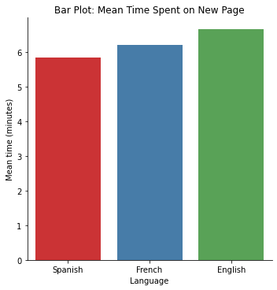

```python
# Use a bar plot to visualize mean time spent on new page for each language

sns.catplot(data=time_df.sort_values('Mean Time'), x='Language', y='Mean Time', kind='bar')
plt.title('Bar Plot: Mean Time Spent on New Page')
plt.ylabel('Mean time (minutes)');
```

The time spent on the new page appears to be highest for users who prefer English and lowest for users who prefer Spanish. The time spent by users who prefer French is in the middle.

Null hypothesis: the mean time spent on the new page is equal across the different preferred languages  
Alternate hypothesis: the mean time spent on the new page is different across different preferred languages

Since we are comparing the sample means across more than 2 independent populations, the ANOVA test may be appropriate. The Shapiro-Wilk and Levene's tests can be used to verify the assumptions of normality and variance (respectively) for the ANOVA test.

For the Shapiro-Wilk test of normality, the null hypothesis is that time spent on the new page follows a normal distribution. The alternate hypothesis is that time spent on the new page does not follow a normal distribution.

```python
w, p_value = stats.shapiro(data_new['time_spent_on_the_page'])
print(f'The p-value is {p_value}')
```

```
The p-value is 0.8040016293525696
```

The p-value for the Shapiro-Wilk test is greater than 0.05, so we fail to reject the null and therefore maintain that time spent on the new page follows a normal distribution, satisfying the assumption for the ANOVA test.

For Levene's test, the null hypothesis is that all the population variances are equal. The alternate hypothesis is that the population variances are unequal.

```python
from scipy.stats import levene
statistic, p_value = levene(
data_new['time_spent_on_the_page'][data_new['language_preferred']=="English"],
data_new['time_spent_on_the_page'][data_new['language_preferred']=="French"],
data_new['time_spent_on_the_page'][data_new['language_preferred']=="Spanish"])

print(f"The p-value for Levene's test is {p_value}")
```

```
The p-value for Levene's test is 0.46711357711340173
```

The p-value for Levene's test is greater than the level of significance (0.05), therefore the null cannot be rejected and we maintain that the population variances are equal, which satisfies the assumption for the ANOVA test.

```python
# Perform the ANOVA test using f_oneway function

from scipy.stats import f_oneway
test_stat, p_value = f_oneway(
data_new.loc[data_new['language_preferred'] == 'English', 'time_spent_on_the_page'],
data_new.loc[data_new['language_preferred'] == 'French', 'time_spent_on_the_page'],
data_new.loc[data_new['language_preferred'] == 'Spanish', 'time_spent_on_the_page'])

print(f'The p-value for the ANOVA test is {p_value}')
```

```
The p-value for the ANOVA test is 0.43204138694325955
```

The p-value for the ANOVA test is greater than the level of significance (0.05) which means there is not enough evidence to reject the null hypothesis. Therefore it is maintained that the time spent on the new page is equal across the different preferred languages.

## Conclusion and Business Recommendations

Summary of evidence:

- Average time spent on the new landing page is significantly greater than average time spent on the old landing page
- The conversion rate is significantly higher for the new landing page compared to the old landing page
- There is not enough evidence to show a relationship between conversion rate and preferred language
- There is not enough evidence to show a difference in average time spent on the new landing page between users with different preferred languages

Recommendations:

- Replace the old landing page with the new landing page for all users due to higher conversion rate and higher average time spent on the new page.
- Collect more data about users with different language preferences in order to customize the user experience further. A larger sample size may allow for better detection of differences.